# useR! 2025 Report

This report summarizes attendee demographics and feedback from the 2025 useR! conference, held August 8–10 in Durham, North Carolina.

Author

Lois Adler-Johnson, Dillon Sparks

## Overview

182 in-person/hybrid participants and 1 virtual participants responded to the survey.

## Demographics of Participants

### Age

(Q: How old are you?)

**Age barplot**

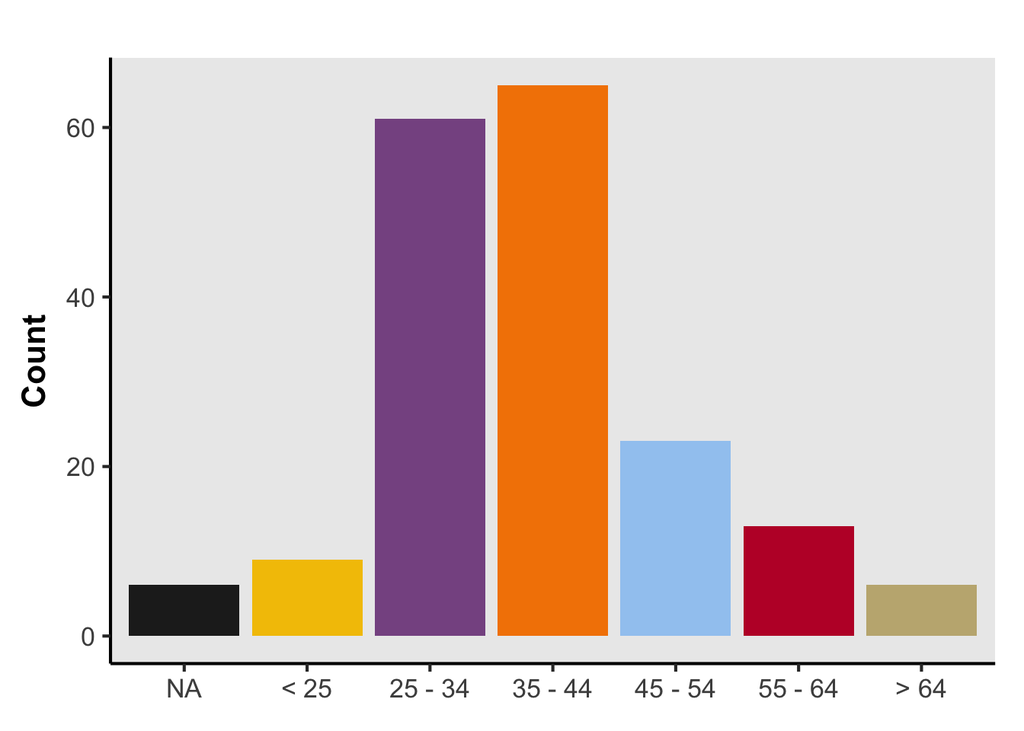

**Age data table**

| Age | n | % |
| --- | --- | --- |
| NA | 6 | 3 |
| < 25 | 9 | 5 |
| 25 - 34 | 61 | 33 |
| 35 - 44 | 65 | 36 |
| 45 - 54 | 23 | 13 |
| 55 - 64 | 13 | 7 |
| > 64 | 6 | 3 |

### Country of origin

(Q: What is your country of origin?)

Counts < 6 are replaced with 1.5 to preserve anonymity, with the NA count adjusted to maintain the total count.

**Map**

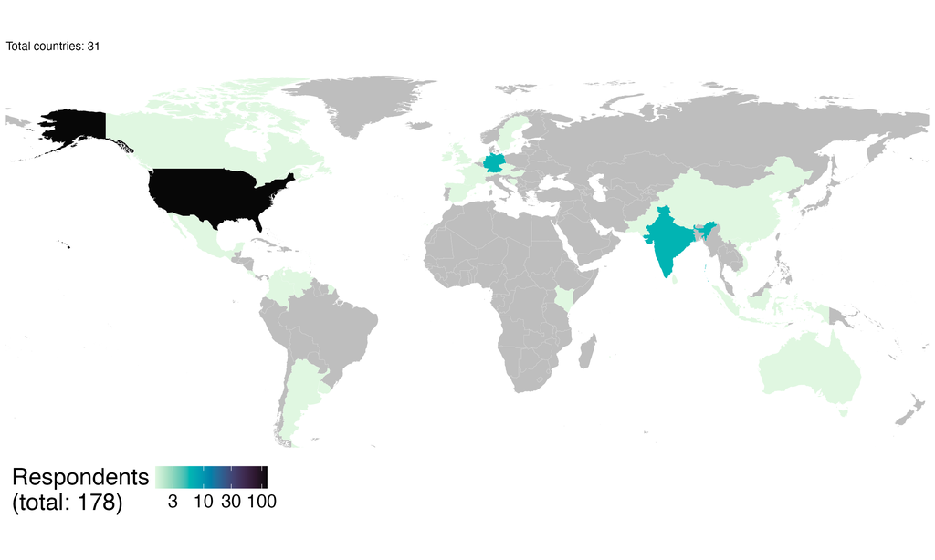

**Data**

| Origin | iso3c | n |
| --- | --- | --- |
| Argentina | ARG | 1.5 |
| Australia | AUS | 1.5 |
| Austria | AUT | 1.5 |
| Bosnia & Herzegovina | BIH | 1.5 |
| Canada | CAN | 1.5 |
| China | CHN | 1.5 |
| Colombia | COL | 1.5 |
| Costa Rica | CRI | 1.5 |
| Czechia | CZE | 1.5 |
| France | FRA | 1.5 |
| Germany | DEU | 6.0 |
| Hungary | HUN | 1.5 |
| India | IND | 6.0 |
| Indonesia | IDN | 1.5 |
| Ireland | IRL | 1.5 |
| Kenya | KEN | 1.5 |
| Mexico | MEX | 1.5 |
| Nepal | NPL | 1.5 |
| Netherlands | NLD | 1.5 |
| Pakistan | PAK | 1.5 |
| Singapore | SGP | 1.5 |
| South Korea | KOR | 1.5 |
| Spain | ESP | 1.5 |
| Sri Lanka | LKA | 1.5 |
| Sweden | SWE | 1.5 |
| Switzerland | CHE | 1.5 |
| United Kingdom | GBR | 1.5 |
| United States | USA | 124.0 |
| Uruguay | URY | 1.5 |
| Venezuela (Bolivarian Republic of) | VEN | 1.5 |
| Viet Nam | VNM | 1.5 |
| NA | NA | 5.0 |

| Continent of origin | n | % |
| --- | --- | --- |
| Africa | 1.5 | 1 |
| Asia | 18.0 | 7 |
| Europe | 22.5 | 9 |
| North America | 128.5 | 53 |
| Oceania | 1.5 | 1 |
| South America | 6.0 | 2 |
| NA | 5.0 | 2 |

### Country of residence

(Q: In what country do you currently reside?)

Counts < 5 are replaced with 1.5 to preserve anonymity, with the NA count adjusted to maintain the total count.

**Map**

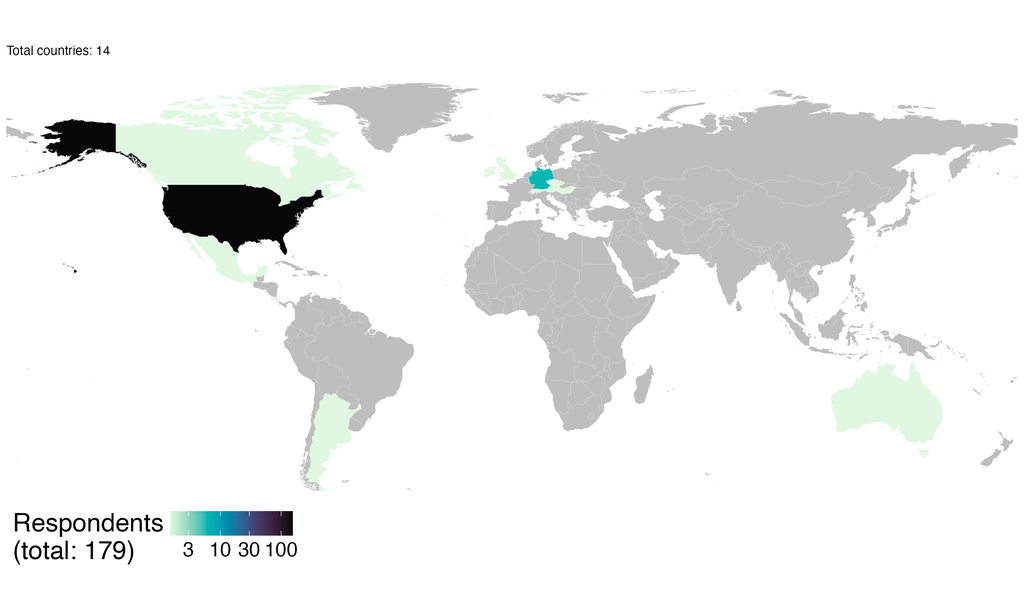

**Data**

| Residence | iso3c | n |
| --- | --- | --- |
| Argentina | ARG | 1.5 |
| Australia | AUS | 1.5 |
| Austria | AUT | 1.5 |
| Canada | CAN | 1.5 |
| Costa Rica | CRI | 1.5 |
| Czechia | CZE | 1.5 |
| Germany | DEU | 6.0 |
| Hungary | HUN | 1.5 |
| Ireland | IRL | 1.5 |
| Mexico | MEX | 1.5 |
| Singapore | SGP | 1.5 |
| Switzerland | CHE | 1.5 |
| United Kingdom | GBR | 1.5 |
| United States | USA | 155.0 |
| NA | NA | 4.0 |

| Continent of residence | n | % |
| --- | --- | --- |
| Asia | 1.5 | 1 |
| Europe | 15.0 | 6 |
| North America | 159.5 | 66 |
| Oceania | 1.5 | 1 |
| South America | 1.5 | 1 |
| NA | 4.0 | 2 |

### Racial/ethnic identity

(Q: What racial/ethnic group(s) do you identify with?)

Respondents could select multiple options.

**Bar plot**

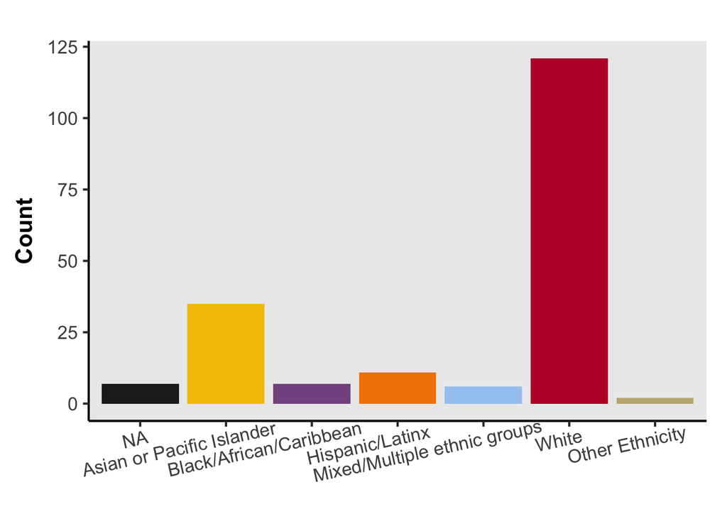

**Data**

| Ethnicity | n | % |
| --- | --- | --- |
| NA | 7 | 4 |
| Asian or Pacific Islander | 35 | 19 |
| Black/African/Caribbean | 7 | 4 |
| Hispanic/Latinx | 11 | 6 |
| Mixed/Multiple ethnic groups | 6 | 3 |
| White | 121 | 64 |
| Other Ethnicity | 2 | 1 |

### Gender

(Q: What is your gender?)

**Bar plot**

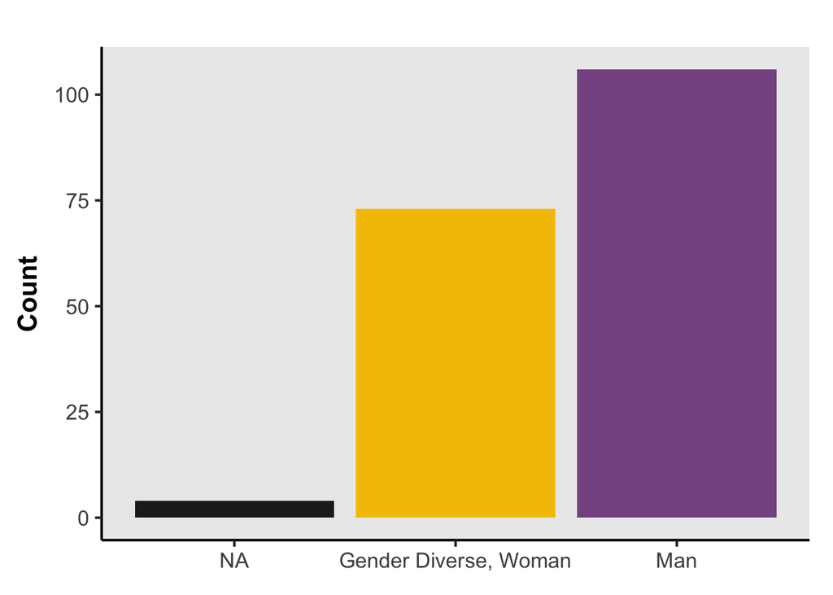

**Data**

| barplot_gender | n | % |
| --- | --- | --- |
| NA | 4 | 2 |
| Gender Diverse, Woman | 73 | 40 |
| Man | 106 | 58 |

### Disability

(Q: Do you have any disabilities or impairments that affect the way you work/study or place special requirements on your working/learning environment?)

**8% of respondents (n = 14)** declared a disability or impairment that affects the way they work or study.

(Q: What kind of disability do you have?)

The following disabilities were represented among useR! 2025 participants:

- A vision impairment
- A hearing impairment
- A mobility impairment
- A learning disability
- A mental health disorder
- Other disability

Participants specified the following under “Other disability”: Chronic medical condition, Chronic migraines, ADHD .

### LGBTQIA+ identity

(Q: Do you identify as LGBTQIA+?)

**7% of respondents (n = 13)** identified as lesbian, gay, bisexual, transgender, queer, intersex, or another sexual or gender minority.

## Education & Life situation

### Education level

(Q: What is the highest level of education you have completed?)

**Bar plot**

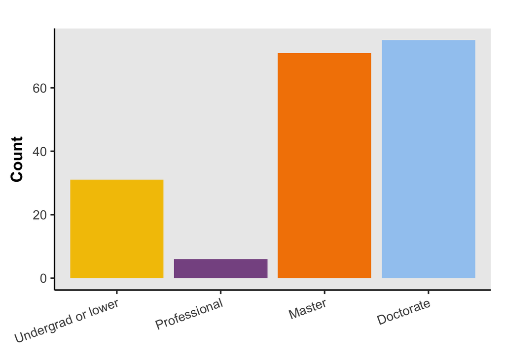

**Data**

| Education | n | % |
| --- | --- | --- |
| Undergrad or lower | 31 | 17 |
| Professional | 6 | 3 |
| Master | 71 | 39 |
| Doctorate | 75 | 41 |

(Q: Are you currently a student?)

**23% of respondents (n = 42)** declared they were currently students, **7% (n = 3) of these students** were part-time.

### Employment status

(Q: What is your current employment status?)

**Bar plot**

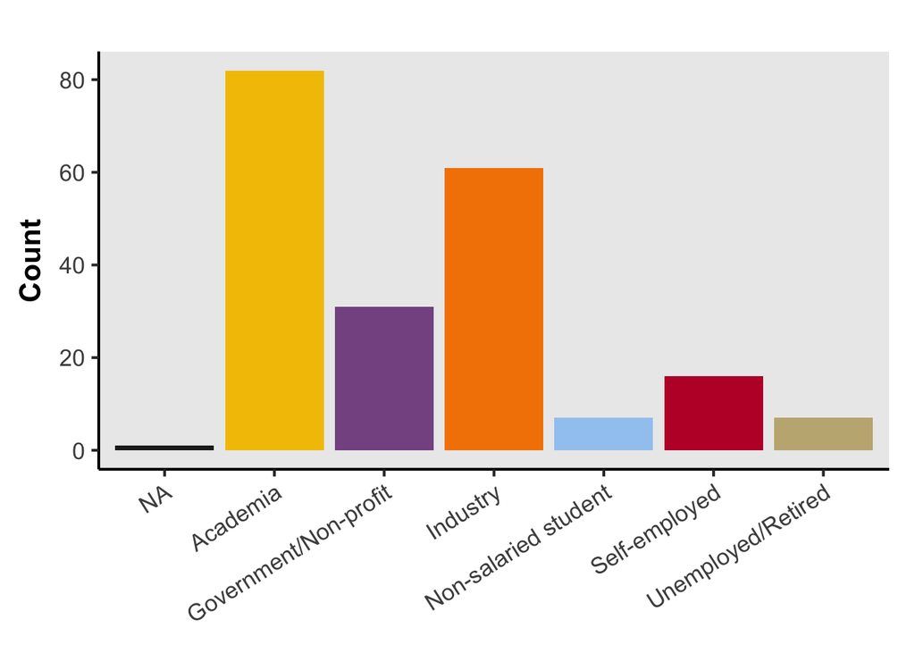

**Data**

| Employment | n | % |
| --- | --- | --- |
| NA | 1 | 0 |
| Academia | 82 | 40 |
| Government/Non-profit | 31 | 15 |
| Industry | 61 | 30 |
| Non-salaried student | 7 | 3 |
| Self-employed | 16 | 8 |
| Unemployed/Retired | 7 | 3 |

(Q: If in paid employment, are you:)

**93% of respondents (n = 171)** declared they had paid employment, **11% (n = 18) of these respondents** only had part-time paid work.

### Caregiving status

(Q: Do you have any children or adults that depend on you for day-to-day care?)

**29% of respondents (n = 53)** have children or adults that depend on them for day-to-day care.

## Interest in R

### R Users

(Q: What is your interest in useR!?)

**97% of respondents (n = 177)** said that they use R.

#### Length of experience

(Q: How long have you been using R for?)

**Bar plot**

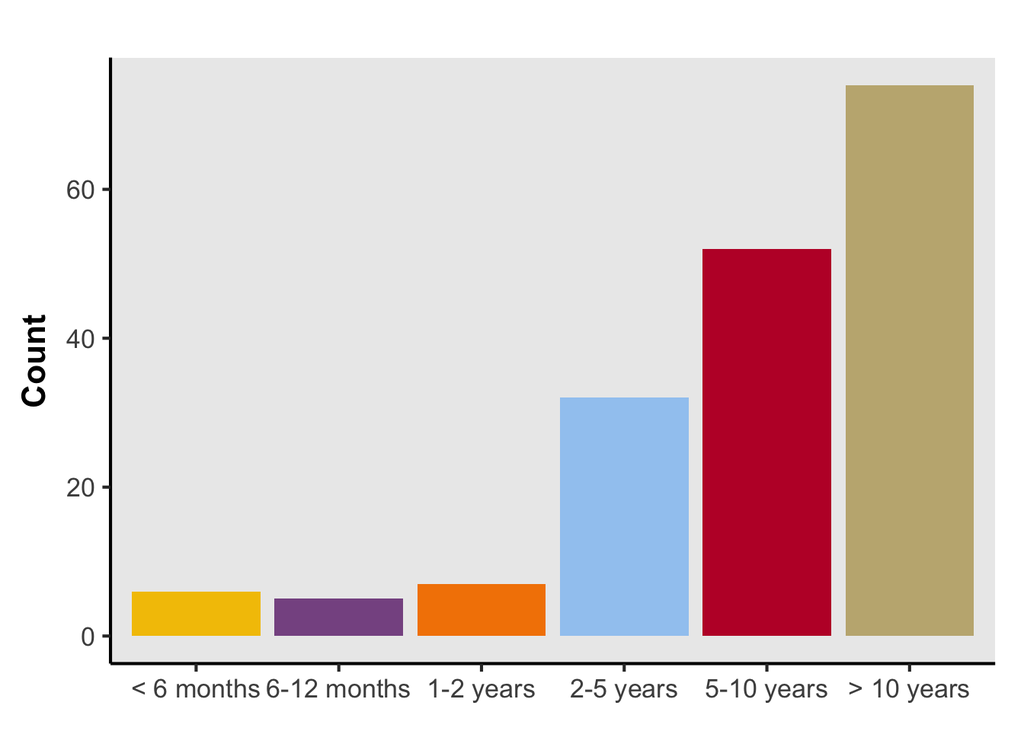

**Data**

| Experience | n | % |
| --- | --- | --- |
| < 6 months | 6 | 3 |
| 6-12 months | 5 | 3 |
| 1-2 years | 7 | 4 |
| 2-5 years | 32 | 18 |
| 5-10 years | 52 | 30 |
| > 10 years | 74 | 42 |

### Non R Users

**3% of respondents (n = 5)** said that they are interested in starting to use R.

## Involvement in useR!

(Q: Was this your first useR!?)

**73% (n = 134)** said they were attending useR! for the first time

### Sessions attended

(Q: What type of sessions did you attend?)

**Upset plot**

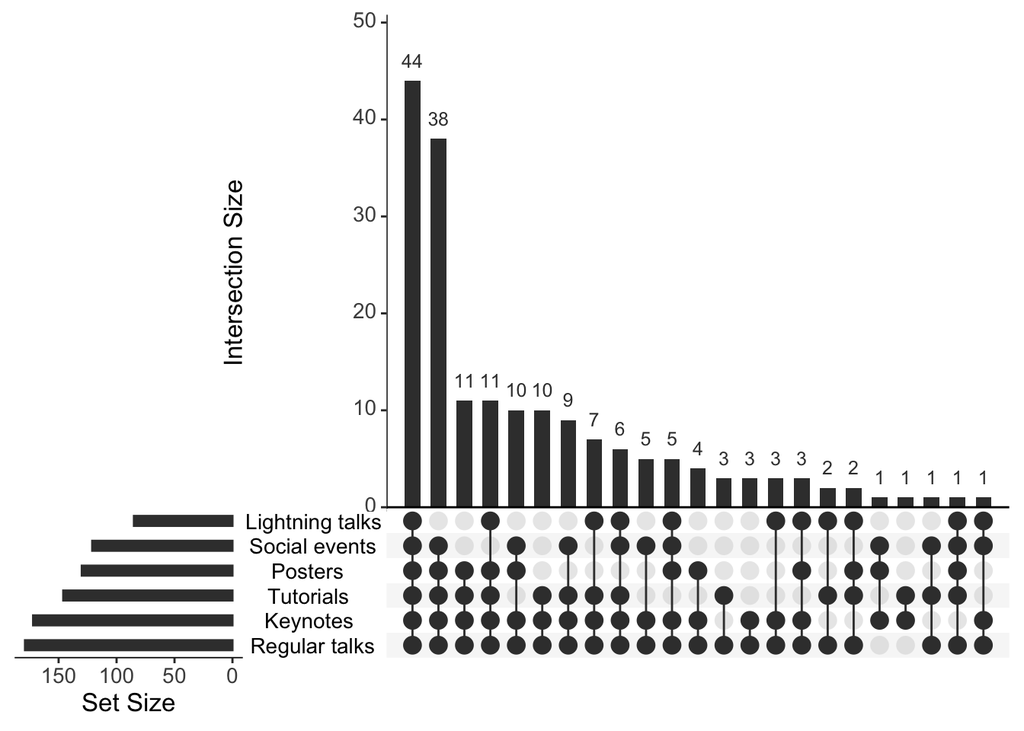

**Session totals**

| Attendance | n | % |
| --- | --- | --- |
| Regular talks (R) | 179 | 99 |
| Keynotes (K) | 172 | 95 |
| Tutorials (T) | 146 | 81 |
| Posters (P) | 130 | 72 |
| Social events (S) | 121 | 67 |
| Lightning talks (L) | 85 | 47 |

**Intersection size**

| Sessions | n |
| --- | --- |
| K-R-L-P-T-S | 44 |
| K-R-P-T-S | 38 |
| K-R-L-P-T | 11 |
| K-R-P-T | 11 |
| K-R-P-S | 10 |
| K-R-T | 10 |
| K-R-T-S | 9 |
| K-R-L-T | 7 |
| K-R-L-T-S | 6 |
| K-R-L-P-S | 5 |
| K-R-S | 5 |
| K-R-P | 4 |
| K-R | 3 |
| K-R-L | 3 |
| K-R-L-P | 3 |
| R-T | 3 |
| None | 2 |
| R-L-P-T | 2 |
| R-L-T | 2 |
| K-P-S | 1 |
| K-R-L-S | 1 |
| K-T | 1 |
| R-L-P-T-S | 1 |
| R-T-S | 1 |

### Financial support

(Q: Were you offered financial support to attend the in-person conference?

Counts < 5 are replaced with 2.5 to preserve anonymity, with the NA count adjusted to maintain the total count.

**Bar plot**

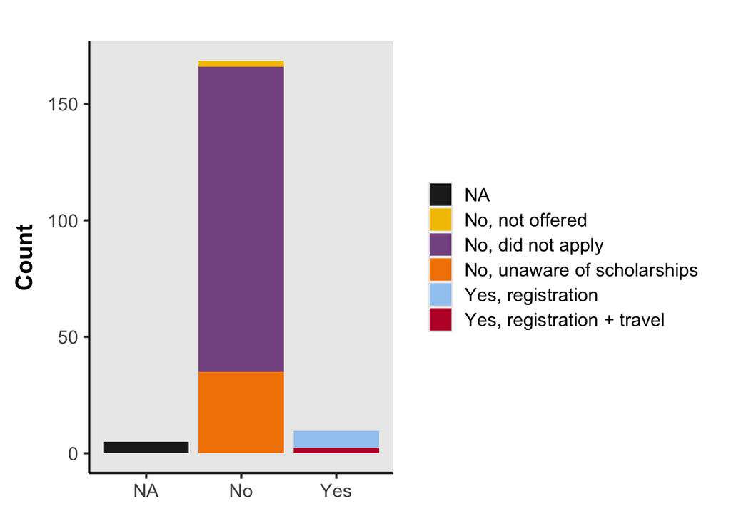

**Data**

| support | n | % |
| --- | --- | --- |
| No, not offered | 2.5 | 1 |
| No, did not apply | 131.0 | 72 |
| No, unaware of scholarships | 35.0 | 19 |
| Yes, registration | 7.0 | 4 |
| Yes, registration + travel | 2.5 | 1 |
| NA | 5.0 | 3 |

## Satisfaction with useR!

Q: How satisfied were you with the following aspects of the useR! program?

### Events

**Bar plot**

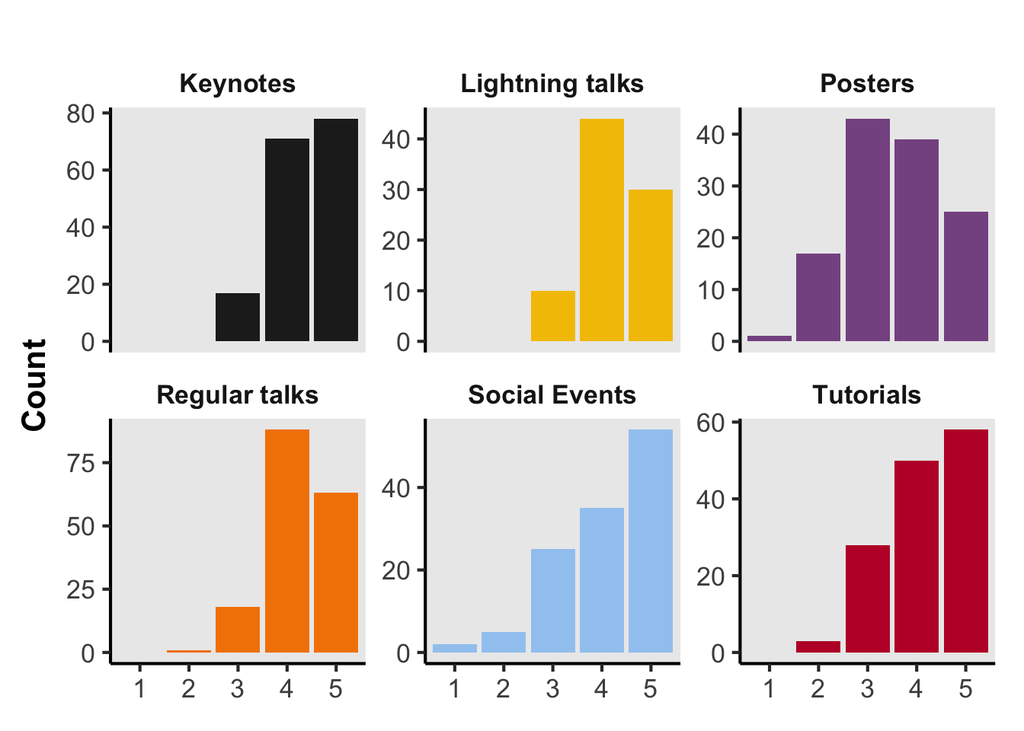

**Data**

| Session Type | Score | n | % |
| --- | --- | --- | --- |
| Keynotes | 3 | 17 | 10 |
| Keynotes | 4 | 71 | 43 |
| Keynotes | 5 | 78 | 47 |
| Lightning talks | 3 | 10 | 12 |
| Lightning talks | 4 | 44 | 52 |
| Lightning talks | 5 | 30 | 36 |
| Posters | 1 | 1 | 1 |
| Posters | 2 | 17 | 14 |
| Posters | 3 | 43 | 34 |
| Posters | 4 | 39 | 31 |
| Posters | 5 | 25 | 20 |
| Regular talks | 2 | 1 | 1 |
| Regular talks | 3 | 18 | 11 |
| Regular talks | 4 | 88 | 52 |
| Regular talks | 5 | 63 | 37 |
| Social Events | 1 | 2 | 2 |
| Social Events | 2 | 5 | 4 |
| Social Events | 3 | 25 | 21 |
| Social Events | 4 | 35 | 29 |
| Social Events | 5 | 54 | 45 |
| Tutorials | 2 | 3 | 2 |
| Tutorials | 3 | 28 | 20 |
| Tutorials | 4 | 50 | 36 |
| Tutorials | 5 | 58 | 42 |

### Accessibility practices

(Q: How would you rate the accessibility practices this year?)

**Bar plot**

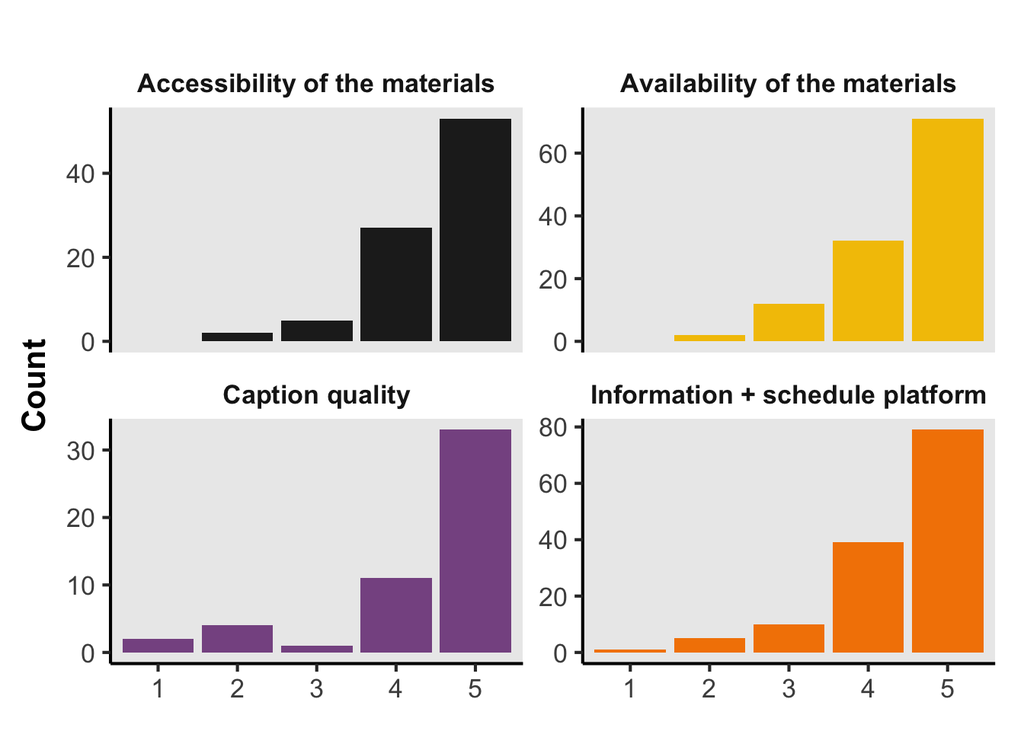

**Data**

| Accessibility Type | Score | n | % |
| --- | --- | --- | --- |
| Accessibility of the materials | 2 | 2 | 2 |
| Accessibility of the materials | 3 | 5 | 6 |
| Accessibility of the materials | 4 | 27 | 31 |
| Accessibility of the materials | 5 | 53 | 61 |
| Availability of the materials | 2 | 2 | 2 |
| Availability of the materials | 3 | 12 | 10 |
| Availability of the materials | 4 | 32 | 27 |
| Availability of the materials | 5 | 71 | 61 |
| Caption quality | 1 | 2 | 4 |
| Caption quality | 2 | 4 | 8 |
| Caption quality | 3 | 1 | 2 |
| Caption quality | 4 | 11 | 22 |
| Caption quality | 5 | 33 | 65 |
| Information + schedule platform | 1 | 1 | 1 |
| Information + schedule platform | 2 | 5 | 4 |
| Information + schedule platform | 3 | 10 | 7 |
| Information + schedule platform | 4 | 39 | 29 |
| Information + schedule platform | 5 | 79 | 59 |

### General organization

(Q: How satisfied were you with the following aspects of the useR! organization?)

**Bar plot**

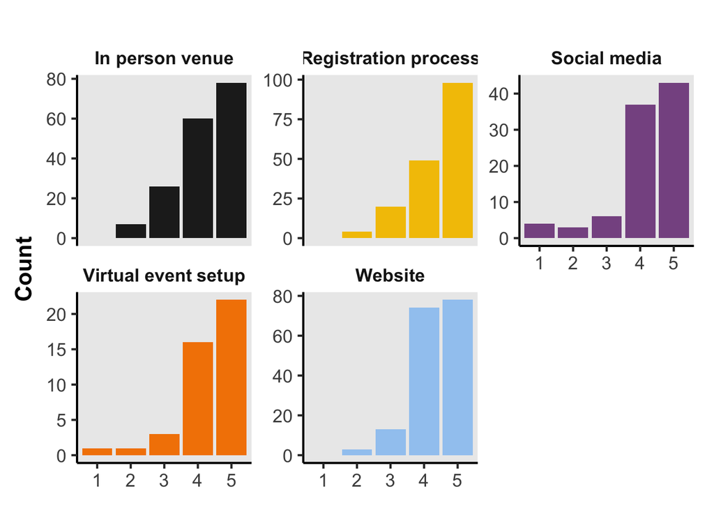

**Data**

| Organization Type | Score | n | % |
| --- | --- | --- | --- |
| In person venue | 2 | 7 | 4 |
| In person venue | 3 | 26 | 15 |
| In person venue | 4 | 60 | 35 |
| In person venue | 5 | 78 | 46 |
| Registration process | 2 | 4 | 2 |
| Registration process | 3 | 20 | 12 |
| Registration process | 4 | 49 | 29 |
| Registration process | 5 | 98 | 57 |
| Social media | 1 | 4 | 4 |
| Social media | 2 | 3 | 3 |
| Social media | 3 | 6 | 6 |
| Social media | 4 | 37 | 40 |
| Social media | 5 | 43 | 46 |
| Virtual event setup | 1 | 1 | 2 |
| Virtual event setup | 2 | 1 | 2 |
| Virtual event setup | 3 | 3 | 7 |
| Virtual event setup | 4 | 16 | 37 |
| Virtual event setup | 5 | 22 | 51 |
| Website | 2 | 3 | 2 |
| Website | 3 | 13 | 8 |
| Website | 4 | 74 | 44 |
| Website | 5 | 78 | 46 |

### Would you attend a future useR!?

(Q: Will you attend a future useR!?)

#### Online

(Q: Would you attend a future online useR! conference?)

**Barplot**

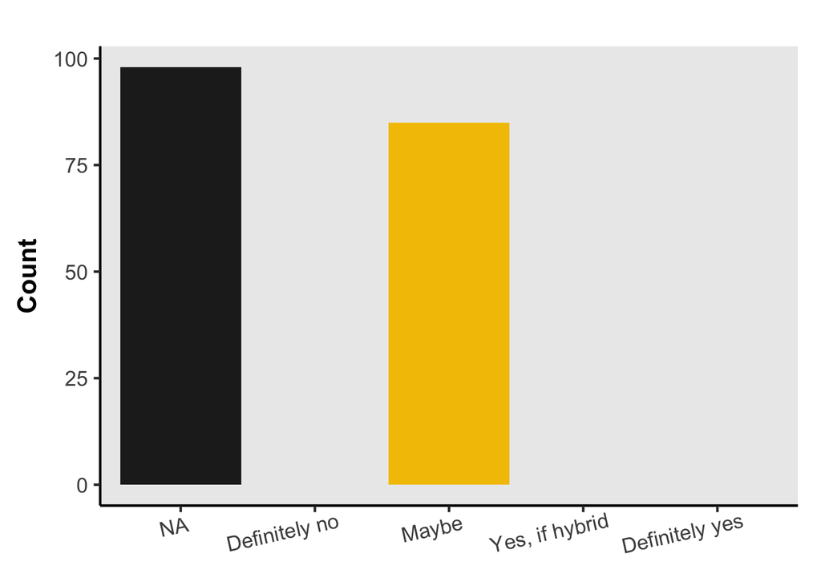

**Data**

| futureOnline | n | % |
| --- | --- | --- |
| NA | 98 | 54 |
| Maybe | 85 | 46 |

#### In-person

(Q: Would you attend a future in-person useR! conference?)

Counts < 5 are replaced with 2.5 to preserve anonymity, with the NA count adjusted to maintain the total count.

**Barplot**

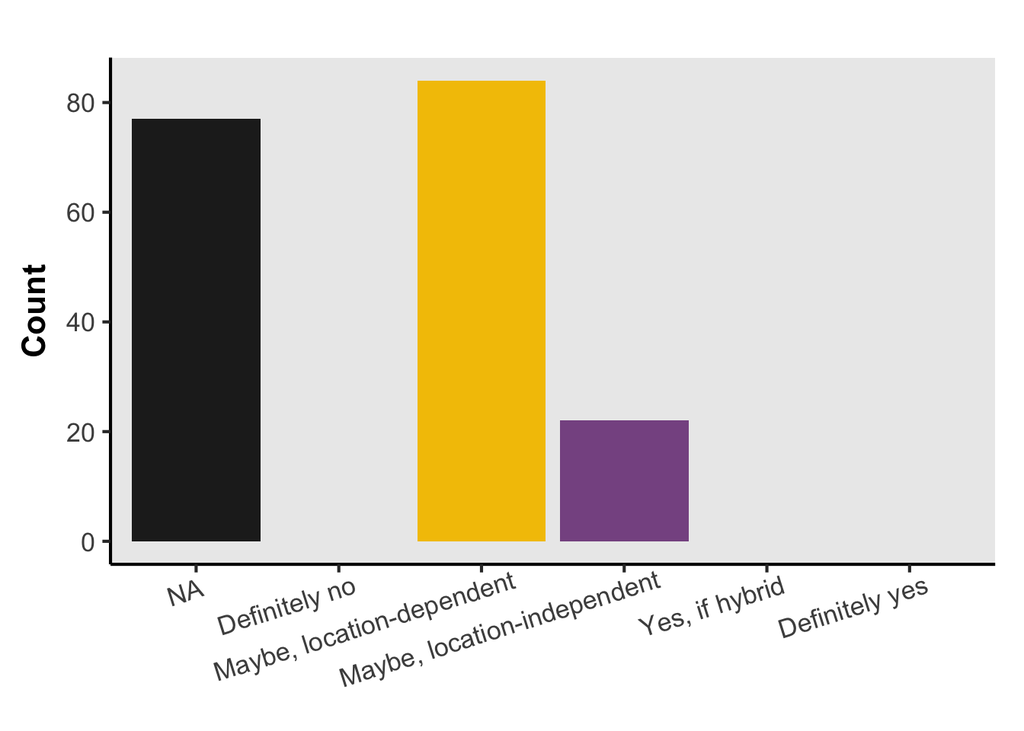

**Data**

| futureInPerson | n | % |
| --- | --- | --- |
| Maybe, location-dependent | 84 | 46 |
| Maybe, location-independent | 22 | 12 |
| NA | 77 | 42 |

## General comments

Q: Do you have other comments on the useR! conference series?

|  | Comment |
| --- | --- |
| 1 | * Help advertise the R Dev Day; I met several (3) persons at the conference that would have liked to attend the R Dev Day if they had known about it. They only learned about it too late, when flights … |
| 2 | &lt;3 |
| 3 | A hard copy of the program with a map and schedule would have been nice. I know that it is extra paper, but having to constantly navigate the page on my phone was less than ideal. I guess I’ll just pl… |
| 4 | Add more lightning talk a well |
| 5 | Consider selecting larger presentation rooms |
| 6 | Depends on both location AND other factors like timing, family, and job responsibilities. |
| 7 | Despite some of my gripes with the tutorials, locations, etc., this was one of the most informative and interesting conferences I've been to. I love the focus on ingenuity being implemented in the R s… |
| 8 | European travel sounds fun, but harder to receive company approval without business motivation. |
| 9 | I am kind of burned out on virtual conferences and so probably will opt for the in-person only. |
| 10 | I appreciate that Use R! goes to great lengths to keep costs down, as my employer has a very limited budget for attending training and conferences. I am generally limited to attending at sites in US/C… |

[output cut: 22 more lines]

## Feedback from non-participants

**3 people** responded to the survey to give feedback as a potential participant that did not attend the conference.

Interest in useR! conference

Non-participant respondents were interested in useR! due to their interest in the following areas:

| Area of Interest | n |
| --- | --- |
| R (as potential user) | 1 |
| R (as current user) | 2 |

Reasons for not participating

(Q: Did you participate in useR! 2025?) (Q: (Conditional on 17) Why did you not participate?)

| Reason | n |
| --- | --- |
| I could not afford the travel expenses for the in person event | 2 |
| I did not have the time | 1 |
| I could not afford the registration fee for the in person event | 0 |
| I did not have sufficient internet access for the virtual event | 0 |
| My visa application was denied for the in person event | 0 |
| The content was not interesting | 0 |
| The in person or virtual event was not accessible for me | 0 |
| NA | 0 |